# Gastos de Parlamentares

# Variáveis

Escolha um subconjunto das variáveis que você considera interessante para investigar como nossos deputados gastam sua verba e comente qual a distribuição dos dados dessas variáveis, em termos de centralidade, extremos, concentração e simetria.  
Há algo surpreendente ou estranho nos dados?  
Como você sugere que um analista de dados lide com a parte surpreendente/estranha?

O subconjunto que irei utilizar para investigar como nossos deputados gastam sua verba, será formado pelas variáveis que considerei interessantes, descritas abaixo:

- txNomeParlamentar: Nome adotado pelo Parlamentar.  
  Será util para identificar cada parlamentar e irá possibilitar obter informações de como cada parlamentar está gastando sua cota mensal.

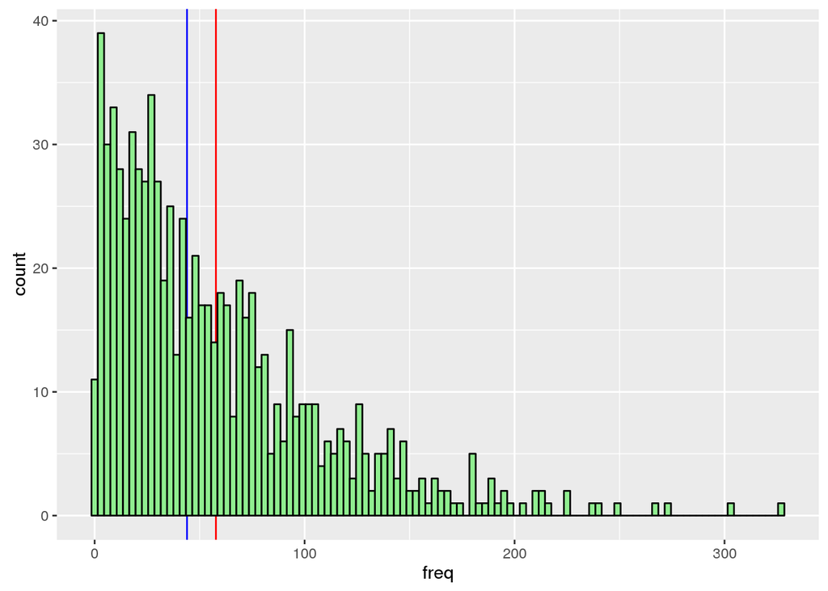

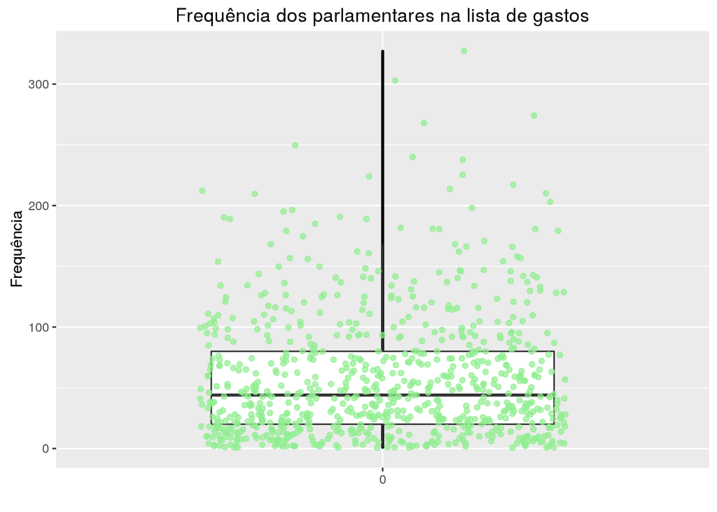

- sgUF: Representa a unidade da federação pela qual o parlamentar foi eleito.  
  Essa variável importante para agrupar as informações obtidas e entender como os parlamentares de cada estado gastam as verbas parlamentares.

```
##      Media Mediana
## 1 1625.643     704
```

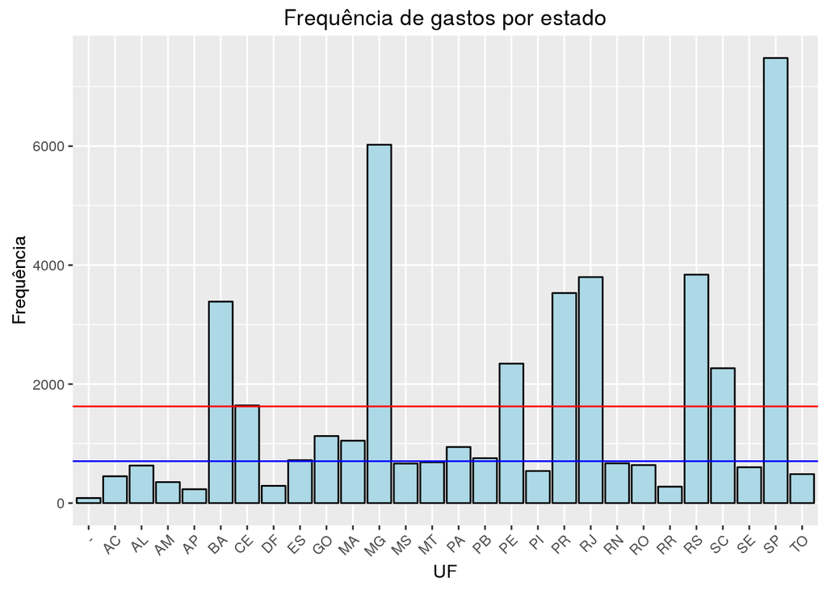

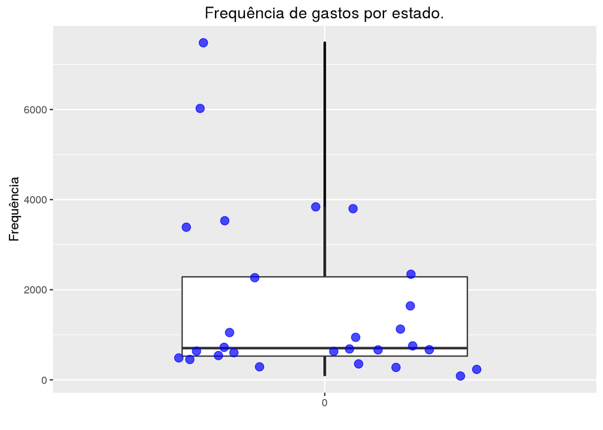

- sgPartido: O seu conteúdo representa a sigla do partido que o parlamentar representa.  
  Essa variável importante para agrupar as informações obtidas e entender como os parlamentares de cada partido gastam as verbas parlamentares.

```
##      Media Mediana
## 1 1569.586    1003
```

[figure not shown]

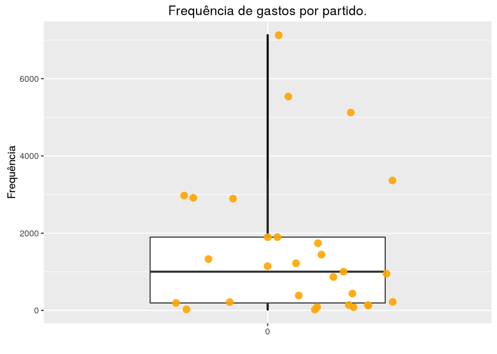

- txtBeneficiario: Representa o nome do fornecedor do produto ou serviço presente no documento fiscal.  
  Variável é interessante para identificar quem são os beneficiários, ou seja, para quem está indo o dinheiro, empresa ou pessoa.
- txtDescricao: O seu conteúdo é a descrição do Tipo de Despesa relativo à despesa em questão.  
  Considerei importante para coletar informações sobre quais são os tipos de despesas dos parlamentares, entender com o que eles mais gastam.
- vlrLiquido: O seu conteúdo representa o valor líquido do documento fiscal ou do documento que deu causa à despesa. É este valor que será debitado da cota do deputado.

```
##      Media Mediana
## 1 549.4232 110.935
```

```
##      80%      90%      99%
##  452.474  968.453 8708.300
```

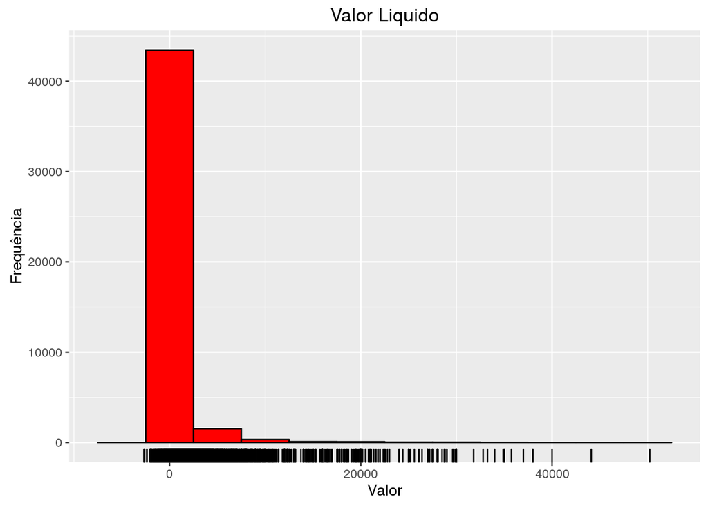

[figure not shown]

## Perguntas

Para esse subconjunto dos dados, resolvi responder algumas perguntas que julguei interessantes:

**1. Proporcionalmente, quais os partidos que gastam mais recursos de sua cota?**

**2. Proporcionalmente, quais os estados que gastam mais recursos de sua cota?**

**3. Quais os três parlamentares que gastam mais recursos de sua cota? E em que tipo de despesa esses gastos estão concentrados?**

**4. Quais os beneficiários que mais recebem os recursos da cota dos parlamentares?**

**5. Em que tipo de despesas nossos parlamentares gastam mais recursos de sua cota?**